# Reproducible Research: Peer Assessment 1

## Part1: Loading and preprocessing the data

```r
setwd('./activity/')
Data<-read.csv('activity.csv',sep=',')
k<-format(seq.POSIXt(as.POSIXct(Sys.Date()), as.POSIXct(Sys.Date()+1), by = "5 min"),"%H:%M",tz="GMT")
k<-k[-length(k)]
library(dplyr)
Data<-mutate(Data,time=rep(k,sum(!is.na(unique(Data$date)))))
```

## Part2: What is mean total number of steps taken per day?

1. Determine the total number of steps taken per day using ‘tapply’ and the result is an array DM

```r
DM<-tapply(Data$steps,Data$date,sum,na.rm=TRUE)
```

2. Reshape the array into data frame

```r
DM<-data.frame('Date'=names(DM),'No.Steps.pd'=DM)
```

3. Plot DM

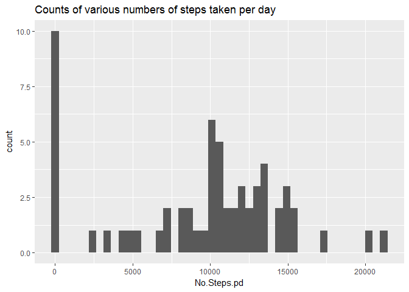

```r
library(ggplot2)
ggplot(DM,aes(No.Steps.pd))+geom_histogram(bins = 45)+labs(title='Counts of various numbers of steps taken per day')
```

4. Calculate the mean and median of the total number of steps taken per day

```r
mean_steps_pd<-mean(DM[,2],na.rm=TRUE)
median_steps_pd<-median(DM[,2],na.rm=TRUE)
```

Therefore, the mean and the median are **9354.2295082** and **10395** respectively.

## Part3: What is the average daily activity pattern?

1. Determine the mean number of steps taken per interval across all days using ‘tapply’ and reshape the result as date frame

```r
DI<-tapply(Data$steps,Data$interval,mean,na.rm=TRUE)
ks<-strptime(k,format='%H:%M')
DIs<-data.frame('Interval'=ks,'No.Steps.pi'=DI)
```

2. Plot the time series

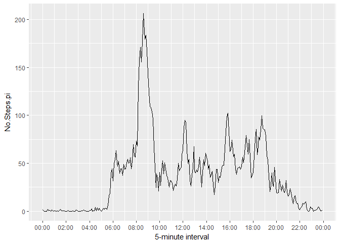

```r
library(scales)
xlim_p<-as.POSIXct(c(ks[1],ks[length(ks)]),tz='GMT')
ggplot(DIs,aes(Interval,No.Steps.pi))+geom_line()+scale_x_datetime(breaks = date_breaks("2 hours"),labels=date_format("%H:%M"),limits=xlim_p)+xlab('5-minute interval')
```

```r
maxnostep<-which.max(DIs$No.Steps.pi)
T_maxnostep<-k[maxnostep]
```

## Part4: Imputing missing values

1. Calculate the total number of missing values.

```r
sona<-sum(is.na(Data$steps))
```

Hence, in the column ‘steps’, the total number of rows with ‘NA’ is **2304**.

```r
NewData<-Data
NewData$impedsteps<-NewData$steps
for (i in 1:sona){
  NewData$impedsteps[i]<-DI[as.character(NewData$interval[i])]
}
```

3. Redefine the new data set which only contained the imputed information on steps.

```r
NewData<-NewData[,-1]
```

4. Determine the total number of steps taken per day using ‘tapply’ and the result is an array NewDM

```r
NewDM<-tapply(NewData$impedsteps,NewData$date,sum,na.rm=TRUE)
```

5. Reshape the array into data frame

```r
NewDM<-data.frame('Date'=names(NewDM),'No.Steps.pd.after.imputing'=NewDM)
```

6. Plot NewDM

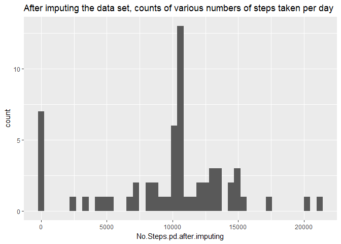

```r
ggplot(NewDM,aes(No.Steps.pd.after.imputing))+geom_histogram(bins = 45)+labs(title='After imputing the data set, counts of various numbers of steps taken per day')
```

7. For the new dataset, calculate the mean and median of the total number of steps taken per day

```r
AI_mean_steps_pd<-mean(NewDM[,2],na.rm=TRUE)
AI_median_steps_pd<-median(NewDM[,2],na.rm=TRUE)
```

## Part5: Are there differences in activity patterns between weekdays and weekends?

1. Refine the data set to include the factor column to indicate whether it is weekend or weekday.

```r
NewData$wds<-weekdays(as.Date(NewData$date))
NewData$fwds<-factor(1*(NewData$wds == 'Saturday'|NewData$wds == 'Sunday'),labels=c('weekday','weekend'))
```

2. Use the simliar appraoch as above to calculate the mean number of steps taken per interval across all weekdays or all weekends using ‘tapply’.

```r
id_wd<-((as.character(NewData$fwds)=='weekday'))
id_we<-((as.character(NewData$fwds)=='weekend'))
NewDM_wd<-tapply(NewData$impedsteps[id_wd],NewData$interval[id_wd],mean,na.rm=TRUE)
NewDM_we<-tapply(NewData$impedsteps[id_we],NewData$interval[id_we],mean,na.rm=TRUE)
```

3. Construct the data frame for plotting.

```r
NewDM_wd<-data.frame('Interval'=ks,'No.Steps.pi'=NewDM_wd,'Type'='weekday')
NewDM_we<-data.frame('Interval'=ks,'No.Steps.pi'=NewDM_we,'Type'='weekend')
NewDM_week<-rbind(NewDM_wd,NewDM_we)
```

4. Use ‘ggplot’ to panel plot the time series of the 5-minute interval and the average number of steps taken, averaged across all weekdays or all weekends.

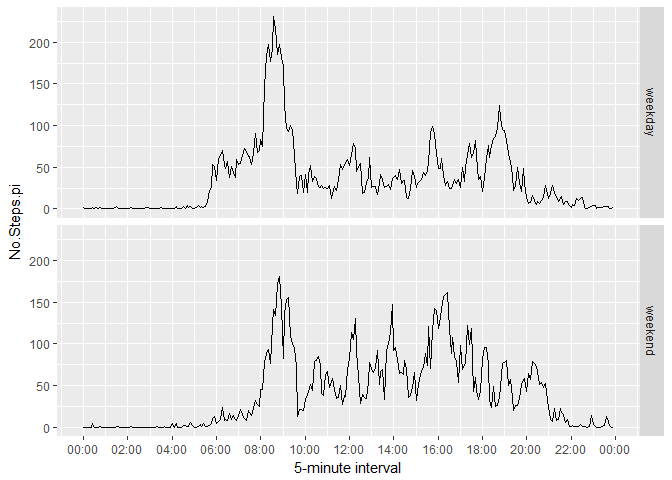

```r
ggplot(NewDM_week,aes(Interval,No.Steps.pi))+geom_line()+facet_grid(Type~.)+scale_x_datetime(breaks = date_breaks("2 hours"),labels=date_format("%H:%M"),limits=xlim_p)+xlab('5-minute interval')
```